# 线性关系绘图

```python
import numpy as np
import pandas as pd
import matplotlib.pyplot as plt
import seaborn as sns
```

# 线性关系绘图

许多数据集含有多个定量变量（数值型变量），而我们分析的目的往往是将他们关联起来。我们曾讨论过通过两个变量的联合分布来实现这一点。然而，使用统计模型来为两组带有噪声数据的观测值评估出一个简单的关系可以是非常有用的。

seaborn中的回归图主要是为了在EDA（探索数据分析）阶段为发掘数据中存在的规律提供一些视觉指引，可以让我们通过可视化快速、轻易地探索数据，毕竟对于探索数据来说，可视化的重要性不比得到一个统计表格低。

## 1 绘制线性回归模型

seaborn主要通过两个函数来展示通过回归得到的线性关系，**regplot()和lmplot()**。它们紧密相关，而且共享大多数的核心功能。但是弄清楚他们的区别非常重要，这样我们就可以在针对特定工作时快速判断哪个工具更适合。

在最基本的调用过程中，他们都会画出关于x、y两个变量的散点图，同时用数据拟合一个y ~ x的模型出来，并将对应的直线和95%的置信区间绘制出来：

```python
# 导入tips数据集
tips = pd.read_csv("../data/tips.csv")
tips
```

|  | total_bill | tip | sex | smoker | day | time | size |
| --- | --- | --- | --- | --- | --- | --- | --- |
| 0 | 16.99 | 1.01 | Female | No | Sun | Dinner | 2 |
| 1 | 10.34 | 1.66 | Male | No | Sun | Dinner | 3 |
| 2 | 21.01 | 3.50 | Male | No | Sun | Dinner | 3 |
| 3 | 23.68 | 3.31 | Male | No | Sun | Dinner | 2 |
| 4 | 24.59 | 3.61 | Female | No | Sun | Dinner | 4 |
| ... | ... | ... | ... | ... | ... | ... | ... |
| 239 | 29.03 | 5.92 | Male | No | Sat | Dinner | 3 |
| 240 | 27.18 | 2.00 | Female | Yes | Sat | Dinner | 2 |
| 241 | 22.67 | 2.00 | Male | Yes | Sat | Dinner | 2 |
| 242 | 17.82 | 1.75 | Male | No | Sat | Dinner | 2 |
| 243 | 18.78 | 3.00 | Female | No | Thur | Dinner | 2 |

244 rows × 7 columns

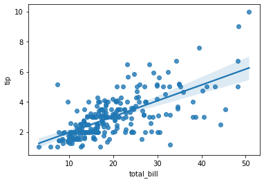

```python
# 使用regplot来绘制回归模型
sns.regplot(x='total_bill',y='tip',data=tips)
```

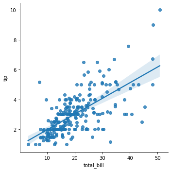

```python
# 使用lmplot来绘制回归模型
sns.lmplot(x='total_bill',y='tip',data=tips)
```

我们注意到除了图片的形状略有差异，其他地方都是一致的。需要知道的是，他们之间最主要的区别在于:

- regplot: x, y参数接受多种数据类型，包括numpy数组、pandas序列（Series或DataFrame),data可以为空。
- lmplot: x 和 y 参数必须以字符串形式指定,且data参数是不能为空的。

## 2 拟合不同的模型

简单线性回归的模型非常容易拟合，然而它并不适用于所有数据集。Anscombe's quartet数据集展示了一些例子，在这些例子中简单线性回归提供了变量间关系一致的估计，但是却与我们视觉上的直观判断存在一些差异。比如，在第一个例子中，线性回归是一个很不错的模型：

```python
# 导入anscombe数据集
anscombe = pd.read_csv("../data/anscombe.csv")
anscombe
```

|  | dataset | x | y |
| --- | --- | --- | --- |
| 0 | I | 10.0 | 8.04 |
| 1 | I | 8.0 | 6.95 |
| 2 | I | 13.0 | 7.58 |
| 3 | I | 9.0 | 8.81 |
| 4 | I | 11.0 | 8.33 |
| 5 | I | 14.0 | 9.96 |
| 6 | I | 6.0 | 7.24 |
| 7 | I | 4.0 | 4.26 |
| 8 | I | 12.0 | 10.84 |
| 9 | I | 7.0 | 4.82 |
| 10 | I | 5.0 | 5.68 |
| 11 | II | 10.0 | 9.14 |
| 12 | II | 8.0 | 8.14 |
| 13 | II | 13.0 | 8.74 |
| 14 | II | 9.0 | 8.77 |
| 15 | II | 11.0 | 9.26 |
| 16 | II | 14.0 | 8.10 |
| 17 | II | 6.0 | 6.13 |
| 18 | II | 4.0 | 3.10 |
| 19 | II | 12.0 | 9.13 |
| 20 | II | 7.0 | 7.26 |
| 21 | II | 5.0 | 4.74 |
| 22 | III | 10.0 | 7.46 |
| 23 | III | 8.0 | 6.77 |
| 24 | III | 13.0 | 12.74 |
| 25 | III | 9.0 | 7.11 |
| 26 | III | 11.0 | 7.81 |
| 27 | III | 14.0 | 8.84 |
| 28 | III | 6.0 | 6.08 |
| 29 | III | 4.0 | 5.39 |
| 30 | III | 12.0 | 8.15 |
| 31 | III | 7.0 | 6.42 |
| 32 | III | 5.0 | 5.73 |
| 33 | IV | 8.0 | 6.58 |
| 34 | IV | 8.0 | 5.76 |
| 35 | IV | 8.0 | 7.71 |
| 36 | IV | 8.0 | 8.84 |
| 37 | IV | 8.0 | 8.47 |
| 38 | IV | 8.0 | 7.04 |
| 39 | IV | 8.0 | 5.25 |
| 40 | IV | 19.0 | 12.50 |
| 41 | IV | 8.0 | 5.56 |
| 42 | IV | 8.0 | 7.91 |
| 43 | IV | 8.0 | 6.89 |

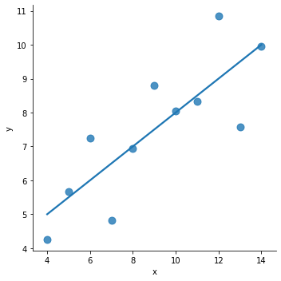

```python
# 当使用数据集I
sns.lmplot(x="x", y="y", data=anscombe.query("dataset == 'I'"),
           ci=None, scatter_kws={"s": 80})
```

- 第二个数据集中有着同样的线性关系，但是我们瞬间就能判断线性回归并不是一个最佳的模型：

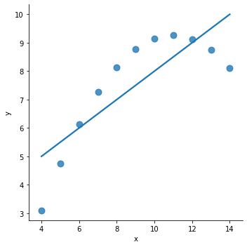

```python
# 使用数据集II
sns.lmplot(x="x", y="y", data=anscombe.query("dataset == 'II'"),
           ci=None, scatter_kws={"s": 80})
```

- 在展示这种更高阶的关系时，lmplot()和regplot()可以通过拟合多项式回归模型来应对数据集中的一些简单的非线性趋势：

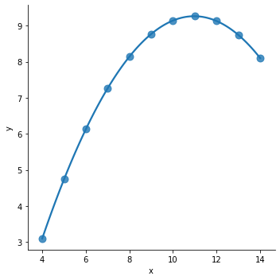

```python
# 添加order参数来拟合一些简单的非线性趋势
sns.lmplot(x="x", y="y", data=anscombe.query("dataset == 'II'"),
           order=2, ci=None, scatter_kws={"s": 80})
```

- 另一个问题是由异常观测点导致的，这些观测点明显偏离了我们想要得到的主要趋势关系：

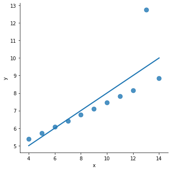

```python
# 使用数据集III
sns.lmplot(x="x", y="y", data=anscombe.query("dataset == 'III'"),
           ci=None, scatter_kws={"s": 80})
```

## 3 考虑其他变量的影响

上边我们展示了很多探索一对变量之间关系的可视化方式。然而在很多情况下，“两个变量之间的关系如何受到第三个变量的影响”是一个更加有趣的问题。在这里regplot()和lmplot()的差异就出现了：regplot()只能展示简单的关系，而lmplot()则融合了regplot()和FacetGrid。因此，lmplot()可以轻易地探索最多三个额外变量带来的交互作用。

分离一个关系最好的方式就是将不通水平的数据绘制在同一个坐标轴体系内，并且用颜色来区分他们：

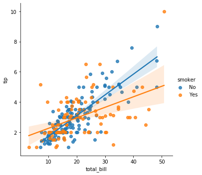

```python
# 添加hue参数来添加第三个变量
sns.lmplot(x="total_bill", y="tip", hue="smoker", data=tips)
```

- 除了颜色，我们还可以通过标记样式来区分不同的水平（分类），这样就可以更好的应对黑白色调或色盲读者。我们可以控制调色板：

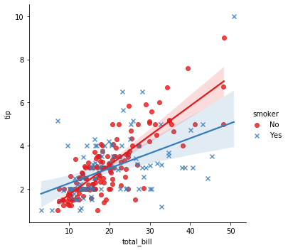

```python
# 改变标记样式来区分不同的分类
sns.lmplot(x="total_bill", y="tip", hue="smoker", data=tips,
           markers=["o", "x"], palette="Set1")
```

- 我们可以通过更多的子图（行、列）来引入新的变量：

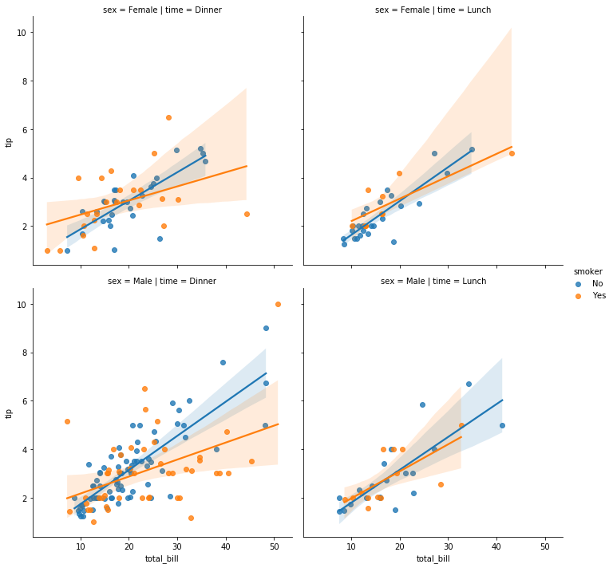

```python
# 添加行列来引入新的变量
sns.lmplot(x="total_bill", y="tip", hue="smoker",
           col="time",row='sex',data=tips)
```

## 4 在其他背景中添加回归图

有一些seaborn函数会在其他更大、更复杂的图形背景中使用regplot()，第一个就是我们在数据分布教程中提到的jointplot()函数。

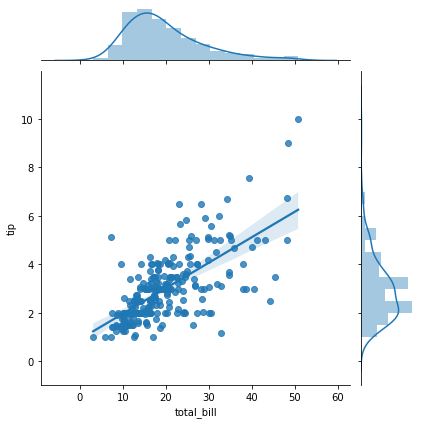

```python
# 在二维分布绘图jointplot中，添加线性关系
sns.jointplot(x="total_bill", y="tip", data=tips, kind="reg")
```